# Filter GISTIC by expression

We’ve made some non-traditional choices in analyzing our copy number variants. First, we subset our GISTIC hits for genes where we see a concurrent increase in gene expression with the aim of assessing the functional impact of the copy number variant (CNV). We then tried to fit models to the relationship between copy number and expression to try to formalize the definition of amplification and deletion: I’d love to be able to say ‘an amplification is the copy number at which we see a significant increase in gene expression’ (and same for expression decrease for a deletion). This only sort of worked, and, in the end, we only define conclusive driver CNVs where AIC for the copy number model was significantly better than the null (but the fits were much more complicated than anticipated). After all this effort it felt hard to decide what qualified as an amplification, which made it hard to define which CNVs co-varied with the subtypes, so instead we settled on just showing the CNV profile difference between the CCS (and avoid defining thresholds for specific CNVs).

## pull data

```r
suppressWarnings(
suppressPackageStartupMessages({

library(CNTools)
library(data.table)
library(dplyr)
library(ggbeeswarm)
library(minpack.lm)
library(ggrepel)
library(ggforce)

}))

packageVersion('CNTools')
```

```
## [1] '1.64.0'
```

```r
'%ni%' <- function(x,y)!('%in%'(x,y))

code.dir = '~/Documents/scripts/github/btc-ccs/'
data.dir = '~/Documents/scripts/github/btc-ccs-data/'

source(paste0(code.dir,"/bin/BTC.functions.R"))
source(paste0(code.dir,"/bin/driver_functions.R"))
source(paste0(code.dir,"/bin/integrated_driver.functions.R"))
# setup genes
gene_set <- fread(file.path(data.dir,'/source_data/fgs.txt'))
gene_set$Chr <- paste0('chr',gene_set$Chr)

genebed <- gene_set %>% filter(biotype=="protein_coding" & Length >= 500 & Chr %in% paste0('chr',c(1:22))) %>%
  dplyr::select(Chr, Start,   End,ensid, gene_name)

names(genebed) <- c('chrom',    'start',    'end',  'geneid',   'genename')

cancerGeneList <- fread(file.path(data.dir,'/source_data/cancerGeneList.tsv'))

# setup samples
predicted.w.score <- fread(file.path(data.dir,'/results/all.eCCS.txt') )
```

## visualize global (and CCS) GISTIC profiles

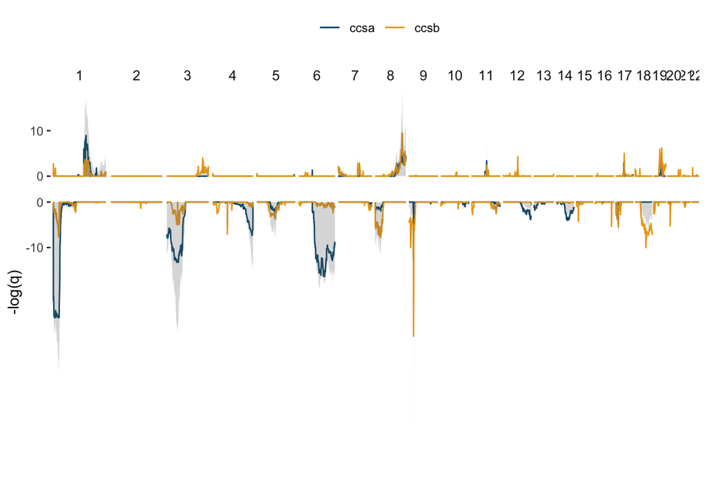

```r
scores.gistic.raw <- fread(file.path(data.dir,'/results/scores.gistic.all.txt'))

cn.gistic.gene.melt <- get.gistic.by.gene(scores.gistic=scores.gistic.raw, genebed=genebed)
cn.gistic.gene.melt$cms <- 'all'


scores.gistic.hep <- fread(file.path(data.dir,'/results/scores.gistic.ccsa.txt'))
cn.gistic.gene.melt.cmsa <- get.gistic.by.gene(scores.gistic.hep, genebed=genebed)
cn.gistic.gene.melt.cmsa$cms <- 'ccsa'

scores.gistic.ehc <- fread(file.path(data.dir,'/results/scores.gistic.ccsb.txt'))
cn.gistic.gene.melt.cmsb <- get.gistic.by.gene(scores.gistic.ehc, genebed=genebed)
cn.gistic.gene.melt.cmsb$cms <- 'ccsb'

scores.gistic <- rbind.data.frame(cn.gistic.gene.melt, cn.gistic.gene.melt.cmsa, cn.gistic.gene.melt.cmsb)


  ggplot(scores.gistic ) +

      facet_grid(type.f~as.numeric(Chrom), scales="free" ,space="free" ) +

      geom_line(aes(x = start/10000000 , y = pflip, color = cms),
                data = ~ subset(., cms %in% c('ccsb','ccsa') & type.f == 'Del')) +
      geom_line(aes(x = start/10000000 , y = pflip, color = cms),
                data = ~ subset(., cms %in% c('ccsb','ccsa') & type.f == 'Amp')) +
      geom_area(aes(x = start/10000000 , y = pflip,  fill = type.f), alpha=0.25,
                data = ~ subset(., cms %in% c('all'))) +

      labs(x="position (mb)", y="-log(q)",color="") +

      scale_alpha_manual(values = c(0.1)) +
        scale_color_manual(values = c(
          "ccsb"    = "#EDA71A" ,
          "ccsa" = "#04597C"
        ))  +  scale_fill_manual(values=c("grey40", "grey40","grey40")) +

      scale_y_continuous(breaks = c(-10,0,10)) +
      guides(fill='none')+
      theme(strip.background = element_blank(),

            panel.spacing.x = unit(0,'lines'),
            legend.position="top",

            axis.title.x =element_blank(),
            axis.text.x=element_blank(),
            axis.ticks.x  =element_blank(),
            panel.grid.major = element_blank(),
            panel.grid.minor = element_blank(),
            panel.background = element_blank(), #transparent panel bg
            plot.background = element_blank(), #transparent plot bg
            panel.border = element_blank(),

            strip.text.y = element_blank(),
            strip.text.x = element_text(size = 10, angle = 0),
            strip.placement = "outside")
```

## gene-gistic to expression matching

```r
all_lesions.conf_90 <- fread(file.path(data.dir,'/results/all_lesions.conf_90.all.txt'))
all.binned.change <- all_lesions.conf_90 %>% filter( `Amplitude Threshold` != 'Actual Copy Change Given')
all.binned.change.sub <- all.binned.change[,c(1:9)]
all.binned.change.sub$CMS <- 'all'

cmsa_lesions.conf_90 <- fread(file.path(data.dir,'/results/all_lesions.conf_90.ccsa.txt'))
cmsa.binned.change <- cmsa_lesions.conf_90 %>% filter( `Amplitude Threshold` != 'Actual Copy Change Given')
cmsa.binned.change.sub <- cmsa.binned.change[,c(1:9)]
cmsa.binned.change.sub$CMS <- 'ccsa'

cmsb_lesions.conf_90 <- fread(file.path(data.dir,'/results/all_lesions.conf_90.ccsb.txt'))
cmsb.binned.change <- cmsb_lesions.conf_90 %>% filter( `Amplitude Threshold` != 'Actual Copy Change Given')
cmsb.binned.change.sub <- cmsb.binned.change[,c(1:9)]
cmsb.binned.change.sub$CMS <- 'ccsb'

binned.change <- rbind.data.frame(all.binned.change.sub, cmsa.binned.change.sub, cmsb.binned.change.sub)

all_rna_raw <- fread(file.path(data.dir,'/results/rna.tpm.ff.txt'), header = T)

#key_tumour_features <- fread(file.path( basedir,'/source_data/BTC_clinical.tumours.tsv'), header = T)
#ff_tumours <- na.omit(key_tumour_features$Sample[key_tumour_features$`Sample Source(FFPE, FF)` == 'FF' ])

#ff.rna.tumours <- intersect(names(all_rna_raw), ff_tumours)

#all_rna_raw <- all_rna_raw %>% dplyr::select(all_of(c('gene_name', ff.rna.tumours)))
names(all_rna_raw)[1] <- 'gene_list'

## this filter loops around peaks, and uses GISTIC gene list for RNA pulls

LEVELS = c('hz'=-2,'het'=-1,'wt'=0,'gain'=1,'amp'=2)
LOG_IT = T
USE_WIDE = T


tpm_filter=T
if(tpm_filter){

  first.peak =T
  for(this.cms in c('all','ccsa','ccsb')){
    cat(this.cms,'\n')

    type.binned.change <- binned.change[binned.change$CMS == this.cms,]
    all_thresholded.by_genes <- fread(paste0(data.dir,'/results/all_thresholded.by_genes.',this.cms,'.txt'))
    these.samples <- intersect(names(all_thresholded.by_genes),names(all_rna_raw))

    for(this.peak in type.binned.change$`Unique Name`){
      this.binned.change <- type.binned.change[type.binned.change$`Unique Name` == this.peak,]

      ## manage the GISTIC format
      if(USE_WIDE){
        split.1 <- unlist(strsplit(  this.binned.change$`Wide Peak Limits`, split = ":"))
      } else {
        split.1 <- unlist(strsplit(  this.binned.change$`Peak Limits`, split = ":"))
      }

      split.2 <- unlist(strsplit(  split.1[[2]], split = "\\("))
      split.3 <- unlist(strsplit(  split.2[[1]], split = "-"))
      split.4 <- unlist(strsplit( this.binned.change$`Unique Name`, split = "\\ "))

      this.chr   <- split.1[[1]]
      this.start <- split.3[[1]]
      this.end   <- split.3[[2]]
      this.type  <- split.4[[1]]
      cat(this.binned.change$Descriptor,'\n')

      ## get RNA
      these.genes <- gene_set %>% filter(Chr == this.chr & Start >= this.start & End <= this.end)
      these.genes.thresholded <- all_thresholded.by_genes[all_thresholded.by_genes$`Gene Symbol` %in% these.genes$gene_name , ]


      ## bulk
      this.rna <- all_rna_raw %>% filter(gene_list %in% these.genes.thresholded$`Gene Symbol`) %>%
        dplyr::select(all_of(c('gene_list', these.samples)))

      ## loop through the genes in the peak
      first.gene = T
      for(this.gene in this.rna$gene_list){

        #make DNA and RNA table
        just.this.rna <- as.data.frame(t(this.rna[this.rna$gene_list == this.gene,])[-1,] )
        just.this.dna <- as.data.frame(t(these.genes.thresholded[these.genes.thresholded$`Gene Symbol` == this.gene,])[-c(1:3),])
        just.this.rna$tumour <- row.names(just.this.rna)
        just.this.dna$tumour <- row.names(just.this.dna)
        suppressMessages(
          just.this <- inner_join(just.this.rna, just.this.dna)
        )
        names(just.this) <- c('TPM','tumour','rel_cn')

        just.this$TPM <- as.numeric(just.this$TPM)
        just.this$rel_cn <- as.numeric(just.this$rel_cn)

        if(LOG_IT & all(just.this$TPM != 0)){
          just.this$TPM <- log(just.this$TPM)

        }

        #tally GISTIC CNV bins and annotate
        this.tally.table <- table(just.this$rel_cn)

        cn.tally<- data.frame(t(t(data.frame(this.tally.table ))[2,]))

        names(cn.tally) <- names(LEVELS[LEVELS %in% names(this.tally.table)])

        if(length(names(LEVELS[LEVELS %ni% names(this.tally.table)])) > 0){
          for(this.null.level in names(LEVELS[LEVELS %ni% names(this.tally.table)])){
            cn.tally <- c(cn.tally, this.null.level = 0)
            names(cn.tally)[length(cn.tally)] <- this.null.level

          }
        }

        cn.tally <- cn.tally[order(names(cn.tally))]

        ##test correlation

        cor.res <- cor.test(just.this$TPM, just.this$rel_cn, method = "pearson")

        spearman.coef <-cbind.data.frame(
          'CMS' = this.cms,
          'gene' = this.gene,
          'type' = this.type,
          'cytoband' = this.binned.change$Descriptor,
          'peak' = this.peak,
          'exp.cor.effect_size'   =cor.res$estimate,
          'exp.cor.t'    =cor.res$statistic,
          'exp.cor.p'   =cor.res$p.value,
          cn.tally
        )
        if(first.gene){these.correlations = spearman.coef; first.gene=F}else{these.correlations = rbind.data.frame(these.correlations, spearman.coef)}

      }

      ## Filter on FDR correction is within peaks

      these.correlations$tpm.fdr <- p.adjust(these.correlations$exp.cor.p, method='fdr')

      these.correlations.filt <- these.correlations %>%
       # filter(tpm.fdr < 0.05 ) %>%
        arrange(desc(as.numeric(amp)))

      #only keep relevant CNV
      if(this.type == "Deletion"){
        these.correlations.filt <- these.correlations.filt %>% filter(as.numeric(hz) > 1)
      } else {
        these.correlations.filt <- these.correlations.filt %>% filter(as.numeric(amp) > 1)
      }

      if(first.peak){tpm.filtered.peaks = these.correlations.filt; first.peak=F}else{tpm.filtered.peaks = rbind.data.frame(tpm.filtered.peaks, these.correlations.filt)}

    }
  }
  tpm.filtered.peaks <- unique(tpm.filtered.peaks)
  write.table( tpm.filtered.peaks,  file = file.path(data.dir,"/results/tpm.filtered.peaks.cms.txt"), row.names = FALSE, quote = FALSE, sep = "\t")
}
```

```
## all
## 1p36.33
```

```
## 1q21.1
## 1q22
## 1q44
```

```
## 3q26.2
## 3q29
## 4p16.3
## 5p15.33
## 6p21.33
## 6q12
## 7p22.3
## 7q22.1
## 7q31.2
## 8q22.3
## 8q24.21
## 8q24.3
## 11q13.3
## 12q13.2
## 12q15
## 13q21.31
## 16p13.13
## 16q22.2
## 17q12
## 18q11.2
## 19q12
## 19q13.12
## 19q13.2
## 19q13.43
## 20q13.33
## 1p36.31
## 1p36.11
```

```
## 1p13.3
## 3p26.3
```

```
## 3p21.1
```

```
## 3p12.1
## 4q22.1
```

```
## 4q35.2
```

```
## 5q14.3
## 6q16.1
## 6q26
## 7q35
## 8p21.2
## 9p23
## 9p21.3
## 10q25.1
## 11q23.3
## 12q24.33
## 13q11
## 14q31.1
## 15q14
```

```
## 16q23.1
## 17p12
## 18q21.2
## 20p12.1
## 21q21.1
## ccsa
## 1q21.1
## 1q21.2
## 1q21.3
## 1q25.1
## 1q32.1
## 5q35.2
## 6q12
## 6q12
## 8q24.21
## 8q24.3
## 11q13.3
## 17q12
## 19q13.12
```

```
## 1p36.11
```

```
## 3p21.2
```

```
## 4q13.2
## 4q34.3
```

```
## 5q14.3
## 6q22.1
## 8p23.3
## 9p21.3
## 10q25.1
```

```
## 11q25
## 12q24.33
## 13q12.12
```

```
## 14q24.3
## 17p13.1
## ccsb
## 1p36.33
## 1p36.22
## 1q21.3
```

```
## 1q24.1
## 1q42.12
## 1q44
```

```
## 3q25.1
## 3q26.2
## 3q29
## 5p15.33
```

```
## 6p21.31
## 7p22.3
## 7q21.2
## 7q22.1
## 7q31.2
## 8q22.3
## 8q24.21
## 8q24.3
## 10q22.1
## 11q13.3
## 11q13.5
## 12p11.21
## 12q13.2
## 12q15
## 13q21.31
## 13q22.1
## 16p13.13
## 17q12
## 18p11.31
## 18q11.2
## 19q12
## 19q13.12
## 19q13.2
## 19q13.31
## 19q13.43
## 20q13.2
## 20q13.33
## 22q11.21
## 1p36.11
```

```
## 1p13.3
## 2q22.1
```

```
## 3p21.1
```

```
## 3p12.1
## 4p15.31
```

```
## 4q13.2
## 4q22.1
```

```
## 4q35.1
```

```
## 5q12.1
## 6p24.3
## 6q26
## 7q35
## 8p22
## 8p21.2
## 9p23
## 9p21.3
## 10p15.3
## 10q23.1
## 11p15.4
```

```
## 11q23.3
## 12q24.33
## 13q11
## 14q32.33
## 15q13.3
## 16p13.3
## 16q23.1
## 17p12
## 17p11.2
## 18q21.2
## 19p13.3
```

```
## 20p12.1
## 21q21.1
```

```r
## Filter for known drivers

tpm.filtered.peaks <- fread(file.path(data.dir,"/results/tpm.filtered.peaks.cms.txt"))
tpm.filtered.peaks <- left_join(tpm.filtered.peaks, cancerGeneList, by=c('gene'='Hugo Symbol'))

##fraction of peaks removed by filter
1 - length(unique(tpm.filtered.peaks$peak)) / length(unique(binned.change$`Unique Name`))
```

```
## [1] 0.08450704
```

```r
##list of cytobands removed
sort(setdiff(unique(binned.change$Descriptor), unique(tpm.filtered.peaks$cytoband) ))
```

```
##  [1] "10p15.3"  "10q23.1"  "11q23.3"  "11q25"    "13q12.12" "13q21.31"
##  [7] "13q22.1"  "14q32.33" "16p13.3"  "16q23.1"  "17p11.2"  "17p13.1"
## [13] "20p12.1"  "2q22.1"   "5q35.2"   "6p21.31"  "6q16.1"   "6q22.1"
```

```r
##number of genes per peak
table(tpm.filtered.peaks$peak)
```

```
##
## Amplification Peak  1 Amplification Peak  2 Amplification Peak  3
##                   159                     8                   427
## Amplification Peak  4 Amplification Peak  5 Amplification Peak  6
##                   101                    19                    51
## Amplification Peak  7 Amplification Peak  8 Amplification Peak  9
##                    11                    29                    64
## Amplification Peak 10 Amplification Peak 11 Amplification Peak 12
##                    27                   187                     3
## Amplification Peak 13 Amplification Peak 14 Amplification Peak 15
##                   133                     1                    11
## Amplification Peak 16 Amplification Peak 17 Amplification Peak 18
##                    29                     2                    47
## Amplification Peak 19 Amplification Peak 20 Amplification Peak 21
##                    59                     5                     7
## Amplification Peak 22 Amplification Peak 23 Amplification Peak 24
##                     6                    20                    13
## Amplification Peak 25 Amplification Peak 26 Amplification Peak 27
##                     2                    45                    25
## Amplification Peak 28 Amplification Peak 29 Amplification Peak 30
##                   399                    12                     1
## Amplification Peak 31 Amplification Peak 32 Amplification Peak 33
##                     2                    48                     4
## Amplification Peak 34 Amplification Peak 35 Amplification Peak 36
##                    61                   263                     4
## Amplification Peak 37 Amplification Peak 38      Deletion Peak  1
##                     1                     4                   376
##      Deletion Peak  2      Deletion Peak  3      Deletion Peak  4
##                   451                     3                   690
##      Deletion Peak  5      Deletion Peak  6      Deletion Peak  7
##                   225                    34                   159
##      Deletion Peak  8      Deletion Peak  9      Deletion Peak 10
##                    50                   152                   125
##      Deletion Peak 11      Deletion Peak 12      Deletion Peak 13
##                   182                    28                   147
##      Deletion Peak 14      Deletion Peak 15      Deletion Peak 16
##                   153                   156                     3
##      Deletion Peak 17      Deletion Peak 18      Deletion Peak 19
##                     3                    37                     1
##      Deletion Peak 20      Deletion Peak 21      Deletion Peak 24
##                     5                    56                     7
##      Deletion Peak 25      Deletion Peak 26      Deletion Peak 28
##                     3                     1                     1
##      Deletion Peak 30      Deletion Peak 31
##                     4                     3
```

```r
tpm.filtered.peaks.ann <- tpm.filtered.peaks %>%
  filter(((type == 'Amplification' & `Is Oncogene` == 'Yes') |
           (type == 'Deletion' & `Is Tumor Suppressor Gene` == 'Yes')) & tpm.fdr < 0.05 )

length(unique(tpm.filtered.peaks.ann$peak)) / length(unique(binned.change$`Unique Name`))
```

```
## [1] 0.5915493
```

```r
setdiff(unique(tpm.filtered.peaks$cytoband), unique(tpm.filtered.peaks.ann$cytoband) )
```

```
##  [1] "1q21.1"   "1q22"     "3q29"     "4p16.3"   "6p21.33"  "6q12"
##  [7] "7q22.1"   "8q22.3"   "8q24.3"   "16q22.2"  "19q13.12" "19q13.2"
## [13] "20q13.33" "1p36.31"  "1p13.3"   "3p12.1"   "4q22.1"   "9p23"
## [19] "10q25.1"  "13q11"    "14q31.1"  "21q21.1"  "1q21.2"   "1q25.1"
## [25] "4q13.2"   "14q24.3"  "1p36.22"  "1q24.1"   "1q42.12"  "3q25.1"
## [31] "10q22.1"  "11q13.5"  "18p11.31" "19q13.31" "4p15.31"  "4q35.1"
## [37] "6p24.3"   "11p15.4"  "15q13.3"
```

```r
length(unique(tpm.filtered.peaks.ann$gene))
```

```
## [1] 82
```

```r
candidates <- unique(tpm.filtered.peaks.ann %>% dplyr::select(cytoband, gene, type, CMS))

#tpm.filtered.peaks.ann <- left_join(tpm.filtered.peaks.ann, cn.gistic.gene, by=c('gene'='genename'))
```

## fit curves to TPM / CNV

This rapidly gets a little overwhelming when trying to account for all the factors that will indirectly impact these two estimates (cell type, tumor content, ploidy, anatomical location, CCS etc), so we went really conservative here.

```r
hits <- sort(c(unique(tpm.filtered.peaks.ann$gene)))

all.cnv <- fread(file.path(data.dir,"/results/all.cnv.txt"))
all.cnv$toy.marker <- 1
all.cnv <- all.cnv %>% dplyr::select(sampleID, chrom,start.pos,end.pos,toy.marker, labels) %>% filter(!is.na(labels))
names(all.cnv) <- c('ID','chrom','loc.start','loc.end','num.mark','seg.mean')



allele.cn.seg <- CNSeg(all.cnv)
allele.cn.gene <- getRS(allele.cn.seg, by="gene", imput=FALSE, XY=FALSE, geneMap=genebed, what="min")
gene.allele <- rs(allele.cn.gene)

gene.allele.filt <- gene.allele %>% filter(genename %in% hits)
cnv.allele.sum <- as.data.frame(apply(gene.allele.filt[,-c(1:5)] , c(1, 2), split_and_sum))
cnv.allele.sum <- cbind.data.frame(gene.allele.filt[,c(1,5)], cnv.allele.sum)

##importing ploidy
cellularity <- fread(file.path(data.dir,'/results/btc.cellularity.curated.txt'), col.names = c('tumor','cellularity','ploidy')) %>% filter(tumor %in% names(cnv.allele.sum)[-c(1:2)])

ploidy.cluster.model <- Mclust(cellularity$ploidy, G=2)
cellularity$ploidy.class <- ploidy.cluster.model$classification

ploidy.bins <- cellularity %>% group_by(ploidy.class) %>% summarise(mean_ploidy = mean(ploidy))
ploidy.bins$ploidy.bin[ploidy.bins$mean_ploidy == min(ploidy.bins$mean_ploidy)] <- 'WT'
ploidy.bins$ploidy.bin[ploidy.bins$mean_ploidy == max(ploidy.bins$mean_ploidy)] <- 'WGD'

ploidy.bins <- ploidy.bins %>% dplyr::select(ploidy.class, ploidy.bin)
cellularity <- left_join(cellularity, ploidy.bins)
```

```
## all
##
##  AKT3
```

```
##
##  ARID1A
```

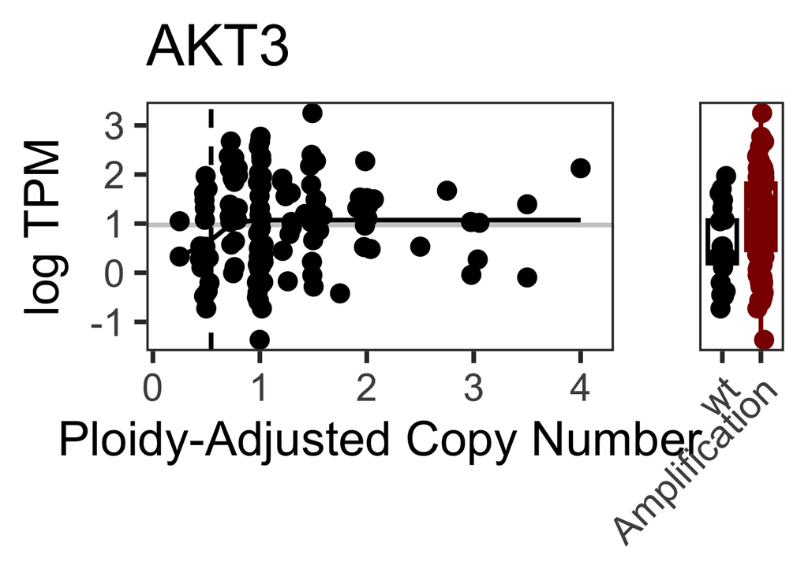

```
##
##  ARID1B
```

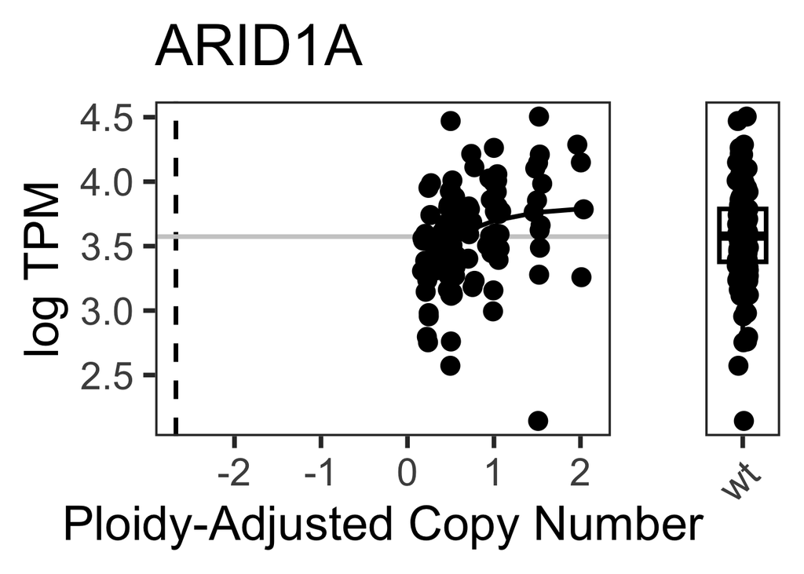

```
##
##  ATP1A1
## Model failed to converge. Try different starting values.
##
##  ATP6V1B2
```

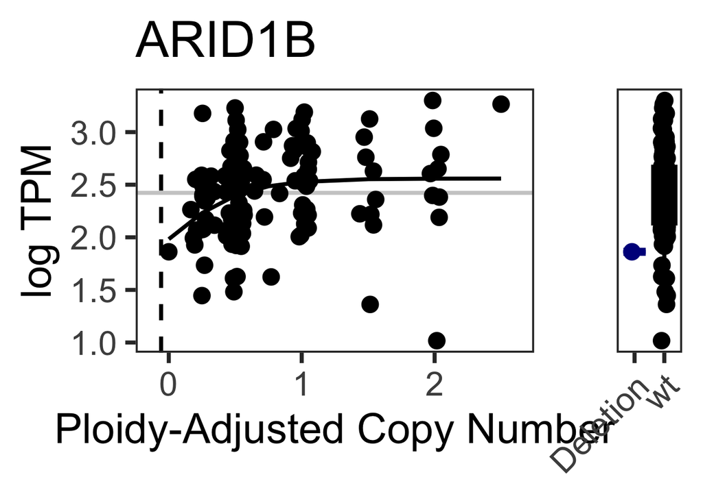

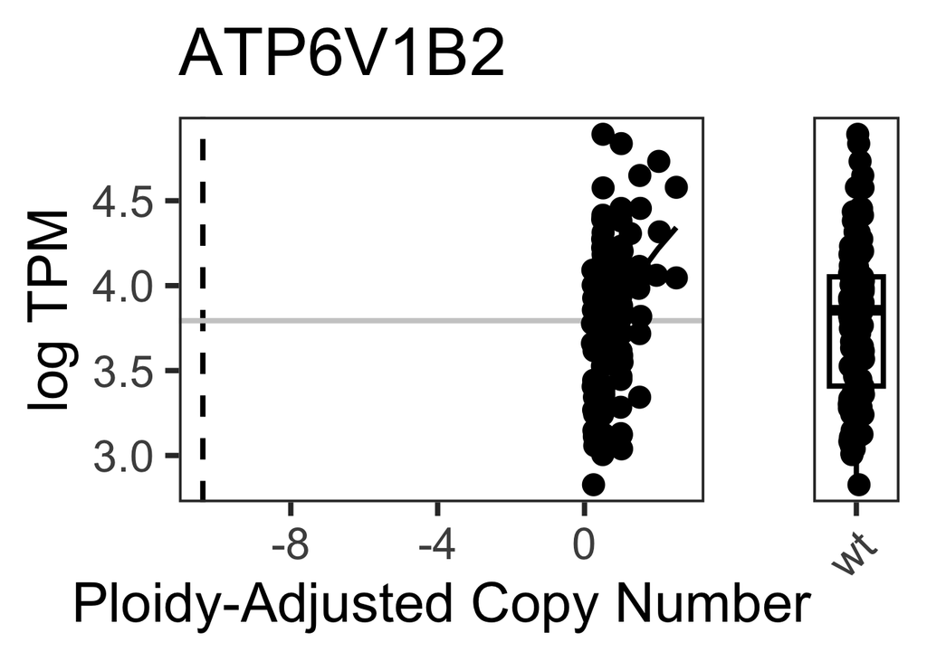

```
##
##  ATRIP
```

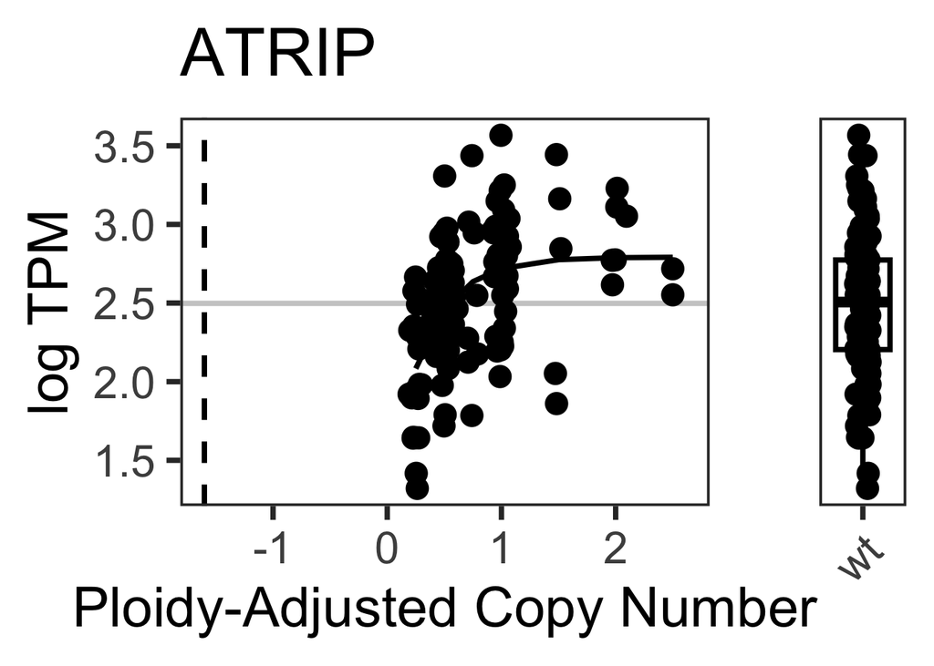

```
##
##  BAP1
```

```
##
##  CCNE1
```

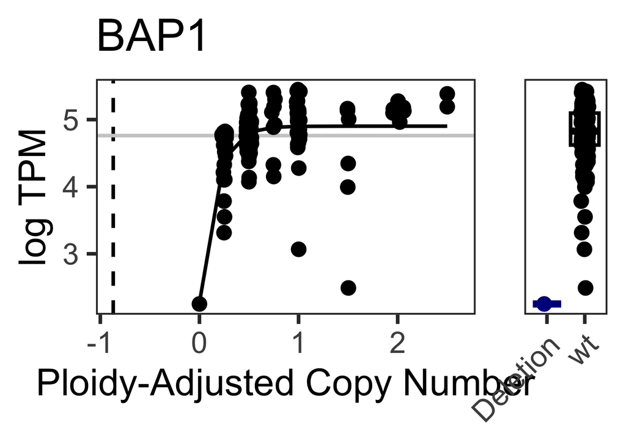

```
##
##  CDKN1B
```

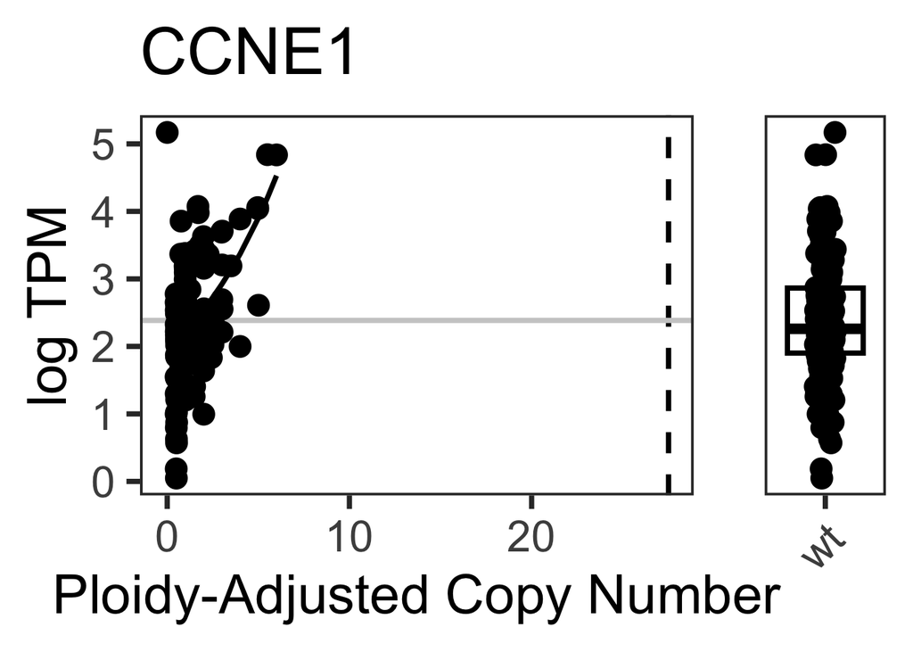

```
##
##  CDKN2A
## some zeroes are leading to infinites in log, removing those!
```

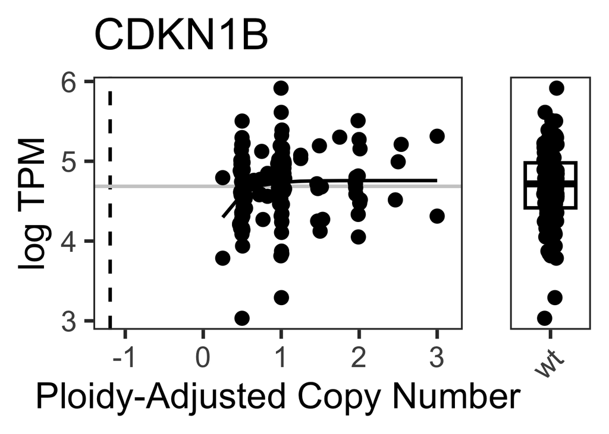

```
##
##  CDKN2B
```

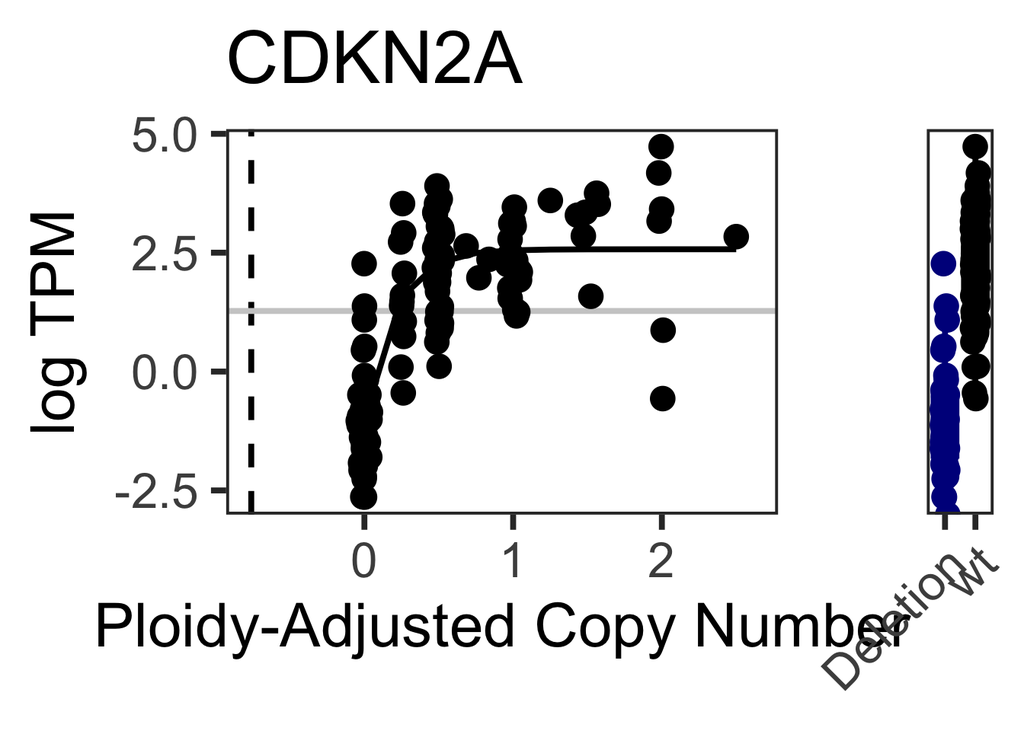

```
##
##  CRBN
```

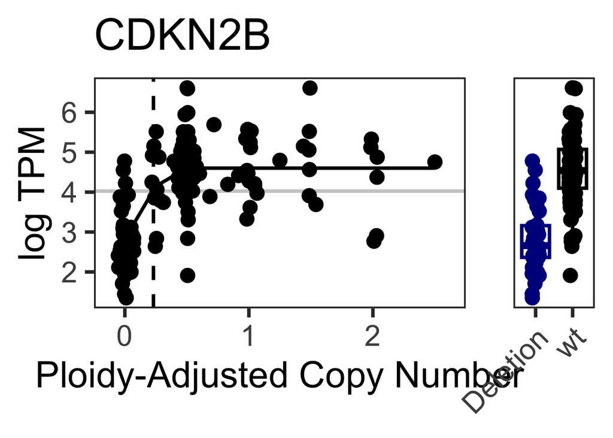

```
##
##  DUSP4
```

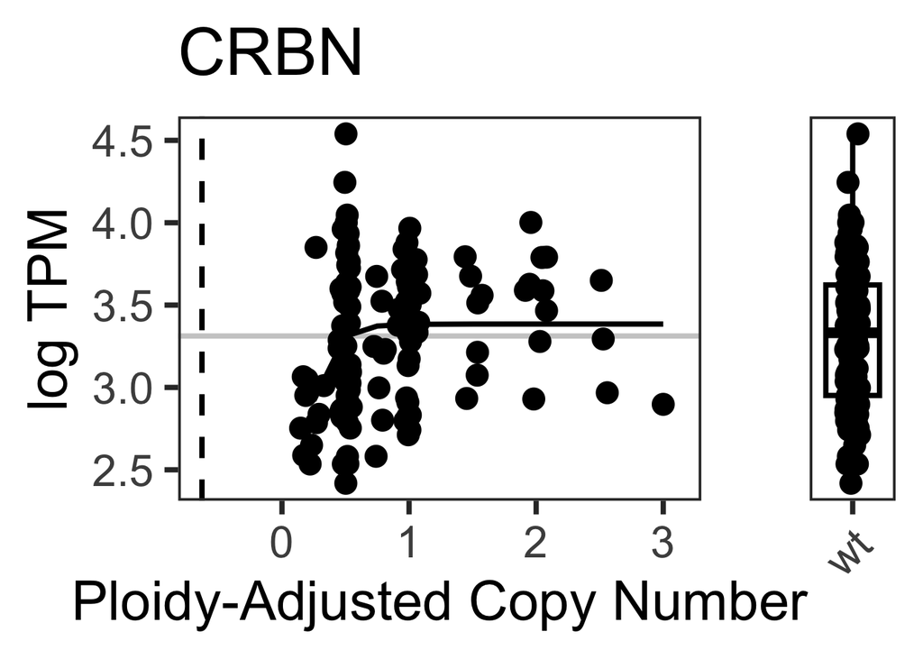

```
##
##  EP400
```

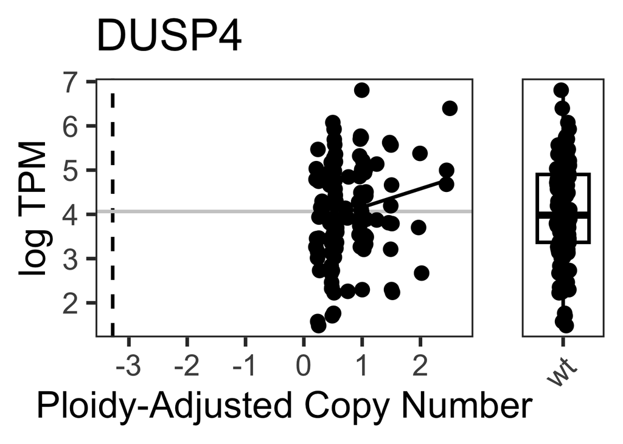

```
##
##  EPHB4
```

[110 more figures not shown]

```r
cellularity$ploidy.bin[cellularity$ploidy < min(cellularity$ploidy[cellularity$ploidy.bin == 'WT'])] <- 'WT'

cellularity$ploidy.base <- NA
cellularity$ploidy.base[ploidy.bins$ploidy.bin == 'WT'] <- 2
cellularity$ploidy.base[ploidy.bins$ploidy.bin == 'WGD'] <- 4

write.table(
  cellularity,
  file = paste0(data.dir, "/results/cellularity.txt"),
  row.names = FALSE, quote = FALSE, sep = "\t"
)

adjust_for_tumour_content = F
parameterize.CNVs = T

if(parameterize.CNVs){

  first.gene=T
  for(this.cms in c('all','ccsa','ccsb')){
    cat(this.cms,'\n')

    hits <- sort(c(unique(tpm.filtered.peaks.ann$gene[tpm.filtered.peaks.ann$CMS == this.cms])))

    all_thresholded.by_genes <- fread(paste0(data.dir,'/results/all_thresholded.by_genes.',this.cms,'.txt'))
    hits.gistic <- all_thresholded.by_genes %>% filter(`Gene Symbol` %in% hits)

    ploidy.sub <- cellularity %>% filter(tumor %in% names(all_thresholded.by_genes))

    medians <- ploidy.sub$ploidy.base
    names(medians) <- ploidy.sub$tumor

    cellularity.sub <- cellularity %>% filter(tumor %in% names(all_rna_raw))

    purities <- cellularity.sub$cellularity
    names(purities) <- cellularity.sub$tumor


    for(this.gene in hits){

      cat('\n',this.gene,'\n')

      ##make CNV table
      this.gistic <- as.data.frame(t(hits.gistic[hits.gistic$`Gene Symbol` == this.gene,])[-c(1:3),])
      this.celluloid <- as.data.frame(t(cnv.allele.sum[cnv.allele.sum$genename == this.gene,])[-c(1:2),])
      this.gistic$tumour <- row.names(this.gistic)
      this.celluloid$tumour <- row.names(this.celluloid)
      suppressMessages(
        just.this.dna <- inner_join(this.gistic, this.celluloid)
      )
      names(just.this.dna) <- c('GISTIC','tumour','alleles')
      just.this.dna$GISTIC <- as.numeric(just.this.dna$GISTIC)
      just.this.dna$alleles <- as.numeric(just.this.dna$alleles)
      just.this.dna$alleles.adj <- as.numeric(just.this.dna$alleles) / medians

      ##make RNA table
      just.this.rna <- as.data.frame(t(all_rna_raw[all_rna_raw$gene_list == this.gene,])[-1,] )
      just.this.rna$tumour <- row.names(just.this.rna)
      names(just.this.rna)[1] <- c('TPM')

      if(adjust_for_tumour_content){
        just.this.rna$tpm <- as.numeric(just.this.rna$TPM) / purities
      }

      ##join tables
      suppressMessages(
        just.this <- inner_join(just.this.dna, just.this.rna)
      )

      just.this$TPM <- as.numeric(just.this$TPM)


      ## start logistic fits

      x = just.this$alleles.adj
      y = log(just.this$TPM)

      ##removes samples where expression is zero
      ##this is a pretty big assumption
      ##but these genes don't tend to pass AIC anyways
      if(any(is.infinite(y))){
        cat('some zeroes are leading to infinites in log, removing those!')
        x = x[!is.infinite(y)]
        y = y[!is.infinite(y)]
      }


      this.fit <- try(nlsLM(y ~ A + (L - A)  / (1 + exp(-k * (x - x0))),
                 start = list(A = min(y), L = max(y), k = 1, x0 = median(x)),
                 control = nls.lm.control(maxiter = 1000))
                 , silent = TRUE)


      if (inherits(this.fit, "try-error")) {
        cat("Model failed to converge. Try different starting values.\n")
      } else {

        #put predicted values back
        just.this$y_fit[just.this$TPM != 0] <- predict(this.fit)

        ##make and test null
        null_model <- lm(log(TPM) ~ 1, data = just.this[just.this$TPM != 0,] )

        ##compare models
        delta_aic <- AIC(null_model) - AIC(this.fit)


        ##add binned labels
        this.cutoff <- coef(this.fit)["x0"]
        if(this.cutoff < 0 ){ this.cutoff = 0}

        these.type <- unique(tpm.filtered.peaks$type[tpm.filtered.peaks$gene == this.gene])

        for(this.type in these.type){
          just.this$call <- 'wt'
          if(this.type == 'Amplification'){

            just.this$call[just.this$alleles.adj >= this.cutoff ] <- 'Amplification'

            this.gistic <- scores.gistic$gvalue[scores.gistic$genename == this.gene &
                                  scores.gistic$variable == 'Amp' &
                                  scores.gistic$cms == this.cms]

            this.gistic.p <- scores.gistic$pvalue[scores.gistic$genename == this.gene &
                                                 scores.gistic$variable == 'Amp' &
                                                 scores.gistic$cms == this.cms]

          } else {

            just.this$call[just.this$alleles.adj <= this.cutoff ] <- 'Deletion'

            this.gistic <- scores.gistic$gvalue[scores.gistic$genename == this.gene &
                                                 scores.gistic$variable == 'Del' &
                                                 scores.gistic$cms == this.cms]

            this.gistic.p <- scores.gistic$pvalue[scores.gistic$genename == this.gene &
                                                   scores.gistic$variable == 'Del' &
                                                   scores.gistic$cms == this.cms]

          }

          ##join back with full DNA table to infer CNVs where there is no RNA
          just.this.post.filtering <- just.this %>% dplyr::select( tumour, GISTIC, TPM )

          suppressMessages(
            this.full.set <- left_join(just.this.dna, just.this.post.filtering)
          )

          this.full.set$call <- 'wt'
          if(this.type == 'Amplification'){
            this.full.set$call[this.full.set$alleles.adj >= this.cutoff ] <- 'Amplification'
          } else {
            this.full.set$call[this.full.set$alleles.adj <= this.cutoff ] <- 'Deletion'

          }

          ##make result table

          lower.bound = coef(this.fit)["A"]
          if(lower.bound < 0 ){ lower.bound = 0}
          this.fold.change <- coef(this.fit)["L"]/lower.bound

          this.cytoband <- unique(tpm.filtered.peaks$cytoband[tpm.filtered.peaks$gene == this.gene &
                                                                tpm.filtered.peaks$CMS == this.cms])

          call.table <- table(just.this$call)
          call.table.inferred <- table(this.full.set$call)

          if(length(call.table.inferred) >1){
            freq.inferred = call.table.inferred[1] / (call.table.inferred[1] + call.table.inferred[2] )
          }else{
            freq.inferred = 1
          }

          this.cnv.tpm.fit <-
            cbind.data.frame(
              'cytoband'=this.cytoband,
              'gene' = this.gene,
              'type' = this.type,
              'cutoff' = this.cutoff,
              'log.fold.change' = this.fold.change,
              'delta_aic' = delta_aic,
              'n'= call.table[1],
              'n.inferred'= call.table.inferred[1],
              'freq.inferred'= freq.inferred,
              'g.score' = this.gistic,
              'gistic.p' = this.gistic.p,
              'cms' = this.cms

            )

          if(first.gene){cnv.tpm.fit = this.cnv.tpm.fit}else{cnv.tpm.fit = rbind.data.frame(cnv.tpm.fit, this.cnv.tpm.fit)}

          this.full.set$gene <- this.gene
          this.full.set <- this.full.set %>% dplyr::select( tumour, gene, TPM, alleles.adj, call )

          if(first.gene){cnv.calls = this.full.set; first.gene=F}else{cnv.calls = rbind.data.frame(cnv.calls, this.full.set)}

          this.full.set$call <- factor(this.full.set$call, levels = c('Deletion','wt', 'Amplification'))


            print(
              cowplot::plot_grid(
                ggplot(just.this[just.this$TPM != 0,], aes(x = alleles.adj)) +

                  geom_vline(xintercept=coef(this.fit)["x0"], linetype='dashed', color='black')+
                  geom_hline(yintercept=unique(predict(null_model)) ,color='grey80')+

                  geom_sina(aes(y = log(TPM), group=alleles.adj)) +
                  geom_line(aes(y = y_fit)) +
                  labs(x='Ploidy-Adjusted Copy Number', y='log TPM') +
                  theme_bw(base_size=30) +labs(title=this.gene) +
                  theme(panel.grid = element_blank())

                ,
                NULL
                ,
                ggplot(this.full.set, aes(x=call, y=log(TPM), color=call)) +
                  geom_boxplot(outlier.shape = NA) + geom_jitter(width=0.1) +
                  theme_bw(base_size=30) +
                  theme(panel.grid = element_blank(),
                        panel.background = element_blank(),
                        plot.background = element_blank(),
                        axis.ticks.y = element_blank(),
                        axis.text.y = element_blank(),
                        axis.text.x = element_text(angle = 45, hjust = 1),
                        axis.title =  element_blank()) +
                  guides(color='none')+

                  scale_color_manual(values = c('Deletion'='darkblue','wt'='black','Amplification'='darkred'))
              ,
              ncol = 3,align = 'hv', axis = "rlbt", rel_widths =   c(0.75,-0.1,0.3))
            )

        }
      }
    }

    write.table( cnv.tpm.fit,  file = paste0(data.dir,"/results/cnv.tpm.",this.cms,".fit.txt"), row.names = FALSE, quote = FALSE, sep = "\t")

    cnv.tpm.fit.filt <- cnv.tpm.fit %>%
      #filter(  delta_aic > 0 & gistic.p > 0  ) %>%
      dplyr::select(cytoband, type, gene, g.score, gistic.p, delta_aic, n.inferred, freq.inferred, cms)

    cnv.tpm.fit.filt[] <- lapply(cnv.tpm.fit.filt, function(x) {
      if (is.numeric(x)) {
        format(round(x, 2), nsmall = 2)
      } else {
        x
      }
    })


    collapsed_df <- cnv.tpm.fit.filt %>%
      group_by(type, gene, g.score, gistic.p, delta_aic, n.inferred,  freq.inferred, cms) %>%
      summarise(
        cytoband = paste(unique(cytoband), collapse = ", "),
        .groups = "drop"
      )%>%
      arrange(cytoband, desc(delta_aic))

    write.table( collapsed_df,  file = paste0(data.dir,"/results/cnv.tpm.",this.cms,".fit.filt.txt"), row.names = FALSE, quote = FALSE, sep = "\t")

    cnv.calls.filt <- cnv.calls %>% filter(gene %in% cnv.tpm.fit.filt$gene )
    write.table( cnv.calls.filt,  file = paste0(data.dir,"/results/cnv.calls.",this.cms,".txt"), row.names = FALSE, quote = FALSE, sep = "\t")
  }
}
```

```r
cnv.dcast <- reshape2::dcast(collapsed_df, type * gene * cytoband ~ cms, value.var = "gistic.p" ) %>% arrange(cytoband)
```

## make GISTIC plot with labels

With “drivers” we’ve identified from the TPM // CNV model, we re-plot GISTIC profile.

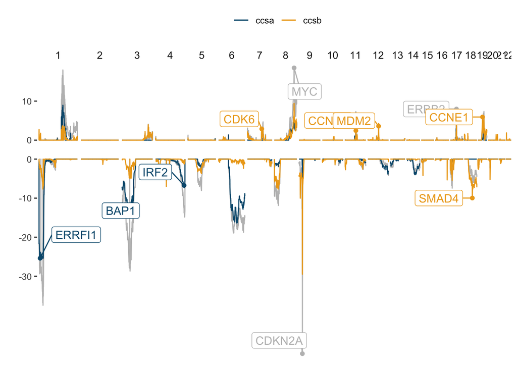

```r
scores.gistic$Chrom <- as.numeric(gsub('chr','',scores.gistic$chrom))

ALL_ONCOGENES = c('MYC','CDKN2A','ERBB2')
cmsa_ONCOGENES = c('IRF2','ERRFI1','BAP1')
cmsb_ONCOGENES = c('CCND1','MDM2','SMAD4','CCNE1','CDK6')

cnv.gistic.subtype <-
  ggplot(scores.gistic, aes( x = start/10000000 , y = pflip)) +

    facet_grid(variable ~ Chrom, scales="free" ,space="free" ) +

  #  geom_area(aes(x = start/10000000 , y = pflip), alpha=0.25, color='grey',
 #             data = ~ subset(., cms %in% c('all'))) +

    geom_line(aes(x = start/10000000 , y = pflip),color='grey',
              data = ~ subset(., cms %in% c('all') ) ) +

    geom_line(aes(x = start/10000000 , y = pflip, color = cms),
             data = ~ subset(., cms %in% c('ccsb','ccsa') & type.f == 'Del')) +
    geom_line(aes(x = start/10000000 , y = pflip, color = cms),
             data = ~ subset(., cms %in% c('ccsb','ccsa') & type.f == 'Amp')) +

    geom_point(  data = ~ subset(., genename %in% ALL_ONCOGENES & cms == 'all' & pvalue > 1), color='grey') +
    geom_point(  data = ~ subset(., genename %in% cmsb_ONCOGENES & cms == 'ccsb'& pvalue > 1), color="#EDA71A") +
    geom_point(  data = ~ subset(., genename %in% cmsa_ONCOGENES & cms == 'ccsa'& pvalue > 1), color="#04597C" ) +


    geom_label_repel(aes(label=genename),
                   data = ~ subset(., genename %in% ALL_ONCOGENES & cms == 'all'& pvalue > 1 ), color='grey',
                   box.padding = 1, force = 4, max.time = 2,  min.segment.length = 0, size=4

    ) +

    geom_label_repel(aes(label=genename), color="#EDA71A",
                   data = ~ subset(., genename %in% cmsb_ONCOGENES & cms == 'ccsb' & pvalue > 1),
                   box.padding = 1, force = 4, max.time = 2,  min.segment.length = 0, size=4

    ) +
    geom_label_repel(aes(label=genename),color="#04597C",
                   data = ~ subset(., genename %in% cmsa_ONCOGENES & cms == 'ccsa' & pvalue > 1),
                   box.padding = 1, force = 4, max.time = 2,  min.segment.length = 0, size=4

    ) +

    labs(x="position (mb)", y=" ",color="") +

    scale_alpha_manual(values = c(0.25)) +
    scale_fill_manual(values=c("darkred", "darkblue")) +
    scale_color_manual(values = c(
     "ccsb"    = "#EDA71A" ,
     "ccsa" = "#04597C"
    )) +
    guides(  fill='none')+


    theme(strip.background = element_blank(),

         panel.spacing.x = unit(0,'lines'),
         legend.position="top",

         axis.title.x =element_blank(),
         axis.text.x=element_blank(),
         axis.ticks.x  =element_blank(),
         panel.grid.major = element_blank(),
         panel.grid.minor = element_blank(),
         panel.background = element_blank(), #transparent panel bg
         plot.background = element_blank(), #transparent plot bg
         panel.border = element_blank(),

         strip.text.y = element_blank(),
         strip.text.x = element_text(size = 10, angle = 0),
         strip.placement = "outside")+
    scale_y_continuous(breaks = c(-30,-20,-10,0,10))  + coord_cartesian(clip = "off")

cnv.gistic.subtype
```

```r
ggsave(filename=paste0(data.dir, "/results/fig/FIG4D.cnv.gistic.subtype.svg"), plot =
  cnv.gistic.subtype
,   device = "svg",width = 210, height = 100, units='mm' )
```